# Creating images with R

Rahul Shankar

2024-03-13

```css
body {
     font-size: 12pt;
     font-family: Comic Sans MS;
     color: #333333;
     line-height: 1.5

}

pre {
    background-colour: #f0f0f0
    padding: 5px;
    border-radius: 8px;
    border: 1px solid #d3d3d3
    overflow-x: auto
    font-family: 'Courier New', monospace;

}

a:hover {
    text-decoration: underline;
}

h1, h2, h3 {
    color: #0056b3;
    margin-top: 0.5em;
    margin-bottom: 0.5em;
}
```

## Project requirements

1. **Here is the link to my github repository:** https://github.com/Rahul-Shankar03/stats220.git
2. **Screenshot of project folder**

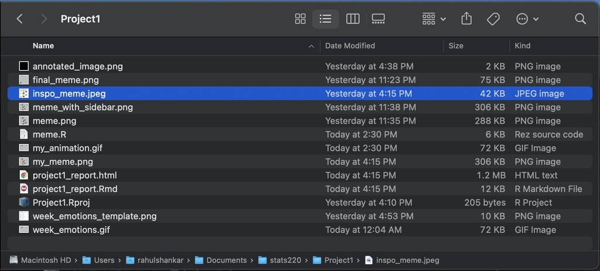

### Working with GitHub

For this project, I successfully set up and utilized my GitHub account, essential for version control and showcasing my work in STATS220. Key accomplishments include:

1. **GitHub Account Creation**: I created a new GitHub account, thoughtfully choosing a username that would be professional and suitable for future employment opportunities.
2. **Repository Setup**: My new repository, named “stats220”, was specifically created for this project. This repository is the central place where all my project work is stored and managed.
   - **GitHub Repository**: [STATS220 Project Repo](https://github.com/Rahul-Shankar03/stats220.git)
3. **Crafting a README File**: I edited the README.md file in my “stats220” repository to clearly communicate the purpose and content of the repo. This file demonstrates my proficiency with Markdown, including:
   - Utilization of two different levels of headers to organize content.
   - Implementation of both ordered and unordered bullet points to list information clearly.
   - Application of bold and italic text for emphasis.
   - Inclusion of hyperlinks to external websites for additional context and resources.

This process has equipped me with valuable skills in using GitHub, a key tool for collaborative software development and project management.

## My meme

[figure not shown]

### Key concepts of the meme

The main idea of the meme inspo is the show different emotion throughout the week

I implemented this type of meme template into my r studio meme I created. The meme shows moods from monday to friday, starting of sad and gradually becoming more lively. Then in the animated version of the gif the images and text appear one by time

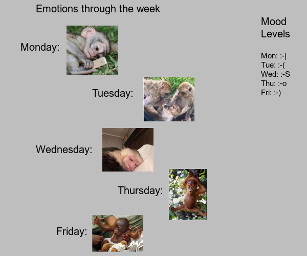

```r
# Create a blank image
img <- image_blank(width = 500, height = 500, color = "grey")

# Annotate the image with text
annotated_img <- image_annotate(img, text = "Emotions through the week",
                                color = "black", size = 20,
                                location = "+70+5")

# Reading and resizing images for each day of the week

# Monday
image_url <- "https://preview.redd.it/orh4wzisf9a61.jpg?auto=webp&s=fad88226d43561b39a5e96a53bb218f0a363995d"
online_image <- image_read(image_url) %>% image_resize("100x100")
# Composite with annotation
composite_image <- image_composite(annotated_img, online_image, offset = "+130+50")

# Tuesday
second_image_url <- "https://i.imgflip.com/2aj9d0.jpg"
second_online_image <- image_read(second_image_url) %>% image_resize("100x100")
# Update composite image
composite_image <- image_composite(composite_image, second_online_image, offset = "+280+150")

# Wednesday
third_image_url <- "https://i.pinimg.com/736x/42/19/e0/4219e09127331406614d6139dbedf8c9.jpg"
third_online_image <- image_read(third_image_url) %>% image_resize("100x100")
# Update composite image
composite_image <- image_composite(composite_image, third_online_image, offset = "+200+250" )

# Thursday
fourth_image_url <- "https://i.imgflip.com/193p17.jpg?a474408"
fourth_online_image <- image_read(fourth_image_url) %>% image_resize("100x100")
# Update composite image
composite_image <- image_composite(composite_image, fourth_online_image, offset = "+330+330" )

# Friday
fifth_image_url <- "https://i.imgflip.com/ufa4k.jpg"
fifth_online_image <- image_read(fifth_image_url) %>% image_resize("100x100")
# Final composite image
composite_image <- image_composite(composite_image, fifth_online_image, offset = "+180+420" )

#Create a sidebar image
sidebar <- image_blank(width = 100, height = 500, color = "grey") %>%
  image_annotate(text = "Mood\nLevels", size = 20, location = "+10+30", color = "black") %>%
  image_annotate(text = "Mon: :-|\nTue: :-( \nWed: :-S \nThu: :-o\nFri: :-)", size = 15, location = "+10+100", color = "black")

# Append the sidebar to the right of the final composite image
final_composite_image_with_sidebar <- image_append(c(composite_image, sidebar), stack = FALSE)

# Annotate the final composite image with sidebar
annotated_final_image_with_sidebar <- image_annotate(final_composite_image_with_sidebar,
                                                     text = "Monday: ",
                                                     size = 20,
                                                     color = "black",
                                                     location = "+40+80",
                                                     font = "Arial") %>%
  image_annotate(text = "Tuesday: ",
                 size = 20,
                 color = "black",
                 location = "+180+170",
                 font = "Arial") %>%
  image_annotate(text = "Wednesday: ",
                 size = 20,
                 color = "black",
                 location = "+70+280",
                 font = "Arial") %>%
  image_annotate(text = "Thursday: ",
                 size = 20,
                 color = "black",
                 location = "+230+360",
                 font = "Arial") %>%
  image_annotate(text = "Friday: ",
                 size = 20,
                 color = "black",
                 location = "+110+440",
                 font = "Arial")

# Save the final image with annotations and sidebar
image_write(annotated_final_image_with_sidebar, "my_meme.png")

annotated_final_image_with_sidebar
```

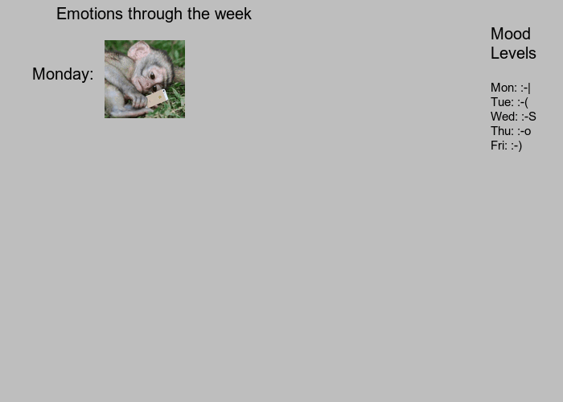

```r
base_img <- image_blank(width = 600, height = 500, color = "grey") %>%
  image_annotate(text = "Emotions through the week", color = "black", size = 20, location = "+70+5")

# Create a sidebar
sidebar <- image_blank(width = 100, height = 500, color = "grey") %>%
  image_annotate(text = "Mood\nLevels", size = 20, location = "+10+30", color = "black") %>%
  image_annotate(text = "Mon: :-|\nTue: :-( \nWed: :-S \nThu: :-o\nFri: :-)", size = 15, location = "+10+100", color = "black")

# Initialize a list to store frames
frames <- list()

# Function to create a frame for each day
create_frame <- function(day_image_url, annotation_text, image_offset, text_location) {
  day_image <- image_read(day_image_url) %>% image_resize("100x100")
  composite <- image_composite(base_img, day_image, offset = image_offset)
  composite_with_sidebar <- image_append(c(composite, sidebar), stack = FALSE)
  annotated_frame <- image_annotate(composite_with_sidebar, text = annotation_text, size = 20, color = "black", location = text_location)
  return(annotated_frame)
}

# URL and parameters for each day
days_info <- list(
  list(url = "https://preview.redd.it/orh4wzisf9a61.jpg?auto=webp&s=fad88226d43561b39a5e96a53bb218f0a363995d", text = "Monday: ", offset = "+130+50", text_loc = "+40+80"),
  list(url = "https://i.imgflip.com/2aj9d0.jpg", text = "Tuesday: ", offset = "+280+150", text_loc = "+180+170"),
  list(url = "https://i.pinimg.com/736x/42/19/e0/4219e09127331406614d6139dbedf8c9.jpg", text = "Wednesday: ", offset = "+200+250", text_loc = "+70+280"),
  list(url = "https://i.imgflip.com/193p17.jpg?a474408", text = "Thursday: ", offset = "+330+330", text_loc = "+230+360"),
  list(url = "https://i.imgflip.com/ufa4k.jpg", text = "Friday: ", offset = "+180+420", text_loc = "+110+440")
)

# Create frames for each day
for (day in days_info) {
  frames <- c(frames, list(create_frame(day$url, day$text, day$offset, day$text_loc)))
}

#Animate the frames
animation <- image_animate(image_join(frames), fps = 1)

#Save the animated image
image_write(animation, "my_animation.gif")

#Display the animated image
animated_image


# Create a base image
base_img <- image_blank(width = 600, height = 500, color = "grey") %>%
  image_annotate(text = "Emotions through the week", color = "black", size = 20, location = "+70+5")

# Create a sidebar
sidebar <- image_blank(width = 100, height = 500, color = "grey") %>%
  image_annotate(text = "Mood\nLevels", size = 20, location = "+10+30", color = "black") %>%
  image_annotate(text = "Mon: :-|\nTue: :-( \nWed: :-S \nThu: :-o\nFri: :-)", size = 15, location = "+10+100", color = "black")

# Initialize a list to store frames
frames <- list()

# Function to create a frame for each day
create_frame <- function(day_image_url, annotation_text, image_offset, text_location) {
  day_image <- image_read(day_image_url) %>% image_resize("100x100")
  composite <- image_composite(base_img, day_image, offset = image_offset)
  composite_with_sidebar <- image_append(c(composite, sidebar), stack = FALSE)
  annotated_frame <- image_annotate(composite_with_sidebar, text = annotation_text, size = 20, color = "black", location = text_location)
  return(annotated_frame)
}

# URL and parameters for each day
days_info <- list(
  list(url = "https://preview.redd.it/orh4wzisf9a61.jpg?auto=webp&s=fad88226d43561b39a5e96a53bb218f0a363995d", text = "Monday: ", offset = "+130+50", text_loc = "+40+80"),
  list(url = "https://i.imgflip.com/2aj9d0.jpg", text = "Tuesday: ", offset = "+280+150", text_loc = "+180+170"),
  list(url = "https://i.pinimg.com/736x/42/19/e0/4219e09127331406614d6139dbedf8c9.jpg", text = "Wednesday: ", offset = "+200+250", text_loc = "+70+280"),
  list(url = "https://i.imgflip.com/193p17.jpg?a474408", text = "Thursday: ", offset = "+330+330", text_loc = "+230+360"),
  list(url = "https://i.imgflip.com/ufa4k.jpg", text = "Friday: ", offset = "+180+420", text_loc = "+110+440")
)

# Create frames for each day
for (day in days_info) {
  frames <- c(frames, list(create_frame(day$url, day$text, day$offset, day$text_loc)))
}

#Animate the frames
animation <- image_animate(image_join(frames), fps = 1)

#Save the animated image
image_write(animation, "my_animation.gif")

#Display the animated image
animated_image
```

## Creativity

Demonstrating creativity in my project involved going beyond the basic instructions in several key ways:

1. **Exploring the `{magick}` Package**: I didn’t limit myself to the functions we studied in class. Instead, I dived deeper into the ‘{magick}’ package, discovering and using additional features to give my meme and animated GIF extra flair. This exploration allowed me to create more engaging and visually appealing images.
2. **Advanced CSS Techniques**: For the HTML report, I applied more complex CSS styles than what was required. This included experimenting with layout, colors, and typography to make the report visually appealing and professional.
3. **Enriching GitHub Content**: I enhanced my GitHub repository by adding an extra webpage created with R Markdown. This page is linked from the main repository page and offers a detailed showcase of my project, demonstrating effective organization and presentation skills.
4. **Adding Context to Meme/GIF**: In creating the meme and the animated GIF, I focused on making them not only humorous but also contextually rich and relatable. This involved thinking creatively about the content and how it might engage the audience.

By taking these steps, I aimed to push the boundaries of the project, exploring new possibilities and presenting my work in a compelling and distinctive manner.

## Learning reflection

### Key Idea from Module 1: Combining HTML with Modern Technologies

One significant concept I learned from Module 1 is the power of integrating HTML with modern data technologies, like R and CSS. This integration not only enhances the visual presentation of data but also makes it more interactive and accessible. Using R Markdown to seamlessly blend analytical R code with narrative text and then knitting it to HTML, I discovered a robust way to communicate findings. This method transcends traditional reporting, offering a dynamic platform to share data-driven stories.

### Future Exploration in Data Technologies

Looking ahead, I am particularly interested in delving deeper into interactive visualizations and web applications. Tools such as Shiny for creating interactive web apps in R intrigue me. The potential to not only display data but also allow users to interact with it in real-time presents an exciting frontier. Additionally, I’m curious about learning more on APIs for data retrieval and how to harness these for more dynamic data analysis and visualization. The idea of connecting to various data sources in real-time and extracting relevant information to analyze and visualize it in a meaningful way is an area I wish to explore further.